# Handson Pertemuan 5

# Library

```r
library(readxl)
library(GGally)
```

```r
library(corrplot)
library(dplyr)
library(car)
```

# Data

```r
dt <-read.csv2("C:\\Users\\a c e r\\OneDrive\\SEMESTER 4\\ANALISIS REGRESI\\DATA ANREG PRAK\\DATA USING FOR R.csv")
dt
```

```
##     Ticker       NPM_Y      GPM_X1       OPM_X2      ROA_X5       ROE_X6
## 1     CPRO  0.04155000  0.20368000  0.090480000  0.07947000  0.104360000
## 2     MSJA  0.07433000  0.18787001  0.110950000  0.03813000  0.059550000
## 3     STAR  0.39859498  0.89708369 -0.090690000 -0.00276000  0.017460000
## 4     PTSN  0.05504000  0.14298001  0.075800000  0.04937000  0.096420005
## 5     CMNP  0.18215999  0.39001000  0.366450000  0.04372000  0.050540000
## 6     UNIC  0.07027000  0.13729000  0.134820000  0.05837000  0.090610000
## 7     INET  0.24544000  0.44139000  0.463113756  0.04389000  0.064320000
## 8     MDIY  0.14133000  0.56194000  0.206289990  0.15513000  0.311170000
## 9     CARS  0.04095000  0.12562999 -0.011030001  0.05481000  0.200350000
## 10    PGAS  0.08060000  0.17105000  0.145380000  0.04949000  0.120820000
## 11    PSSI  0.02623000  0.14142999  0.019580000  0.01097000  0.011089999
## 12    LPPF  0.13652000  0.66010004  0.018740000  0.16562750  0.377479999
## 13    PBRX  0.32406000  0.13861000  0.007770000  0.02679000  0.377479999
## 14    MKPI  0.39859498  0.54925996  0.463113756  0.08346000  0.148460000
```

[output cut: 327 more lines]

```r
head(dt)
```

```
##   Ticker    NPM_Y    GPM_X1   OPM_X2   ROA_X5     ROE_X6 CurrRatio_X7 DER_X13
## 1   CPRO 0.041550 0.2036800  0.09048  0.07947 0.10436000     1.093000  43.245
## 2   MSJA 0.074330 0.1878700  0.11095  0.03813 0.05955000     2.255000  16.159
## 3   STAR 0.398595 0.8970837 -0.09069 -0.00276 0.01746000     6.908375   5.327
## 4   PTSN 0.055040 0.1429800  0.07580  0.04937 0.09642001     1.245000  24.641
## 5   CMNP 0.182160 0.3900100  0.36645  0.04372 0.05054000     0.923000  40.363
## 6   UNIC 0.070270 0.1372900  0.13482  0.05837 0.09061000     6.720000   1.480
```

```r
str(dt)
```

```
## 'data.frame':    170 obs. of  8 variables:
##  $ Ticker      : chr  "CPRO" "MSJA" "STAR" "PTSN" ...
##  $ NPM_Y       : num  0.0416 0.0743 0.3986 0.055 0.1822 ...
##  $ GPM_X1      : num  0.204 0.188 0.897 0.143 0.39 ...
##  $ OPM_X2      : num  0.0905 0.1109 -0.0907 0.0758 0.3664 ...
##  $ ROA_X5      : num  0.07947 0.03813 -0.00276 0.04937 0.04372 ...
##  $ ROE_X6      : num  0.1044 0.0595 0.0175 0.0964 0.0505 ...
##  $ CurrRatio_X7: num  1.093 2.255 6.908 1.245 0.923 ...
##  $ DER_X13     : num  43.24 16.16 5.33 24.64 40.36 ...
```

```r
summary(dt)
```

```
##        Ticker        NPM_Y              GPM_X1             OPM_X2
##  Length   :170   Min.   :-0.18132   Min.   :-0.07754   Min.   :-0.18274
##  N.unique :170   1st Qu.: 0.03614   1st Qu.: 0.16619   1st Qu.: 0.05946
##  N.blank  :  0   Median : 0.09563   Median : 0.29164   Median : 0.12401
##  Min.nchar:  4   Mean   : 0.12276   Mean   : 0.33487   Mean   : 0.15431
##  Max.nchar:  4   3rd Qu.: 0.18112   3rd Qu.: 0.45855   3rd Qu.: 0.22092
##                  Max.   : 0.39859   Max.   : 0.89708   Max.   : 0.46311
##      ROA_X5             ROE_X6          CurrRatio_X7      DER_X13
##  Min.   :-0.06475   Min.   :-0.15904   Min.   :0.158   Min.   :  0.003
##  1st Qu.: 0.02164   1st Qu.: 0.04215   1st Qu.:1.243   1st Qu.:  4.588
##  Median : 0.04820   Median : 0.09018   Median :2.075   Median : 26.453
##  Mean   : 0.05438   Mean   : 0.11899   Mean   :2.748   Mean   : 40.638
##  3rd Qu.: 0.07923   3rd Qu.: 0.17628   3rd Qu.:3.509   3rd Qu.: 56.737
##  Max.   : 0.16563   Max.   : 0.37748   Max.   :6.908   Max.   :134.960
```

```r
library(dplyr)

dt <- dt %>%
  rename(
    Y = `NPM_Y`,
    X1 = `GPM_X1`,
    X2 = `OPM_X2`,
    X3 = `ROA_X5`,
    X4 = `ROE_X6`,
    X5 = `CurrRatio_X7`
  )
```

```r
dt<-select(dt,-Ticker)
dt
```

```
##               Y          X1           X2          X3           X4       X5
## 1    0.04155000  0.20368000  0.090480000  0.07947000  0.104360000 1.093000
## 2    0.07433000  0.18787001  0.110950000  0.03813000  0.059550000 2.255000
## 3    0.39859498  0.89708369 -0.090690000 -0.00276000  0.017460000 6.908375
## 4    0.05504000  0.14298001  0.075800000  0.04937000  0.096420005 1.245000
## 5    0.18215999  0.39001000  0.366450000  0.04372000  0.050540000 0.923000
## 6    0.07027000  0.13729000  0.134820000  0.05837000  0.090610000 6.720000
## 7    0.24544000  0.44139000  0.463113756  0.04389000  0.064320000 2.242000
## 8    0.14133000  0.56194000  0.206289990  0.15513000  0.311170000 1.673000
## 9    0.04095000  0.12562999 -0.011030001  0.05481000  0.200350000 0.907000
## 10   0.08060000  0.17105000  0.145380000  0.04949000  0.120820000 1.936000
## 11   0.02623000  0.14142999  0.019580000  0.01097000  0.011089999 6.269000
## 12   0.13652000  0.66010004  0.018740000  0.16562750  0.377479999 0.522000
## 13   0.32406000  0.13861000  0.007770000  0.02679000  0.377479999 4.844000
## 14   0.39859498  0.54925996  0.463113756  0.08346000  0.148460000 2.167000
```

[output cut: 327 more lines]

# Eksplorasi data

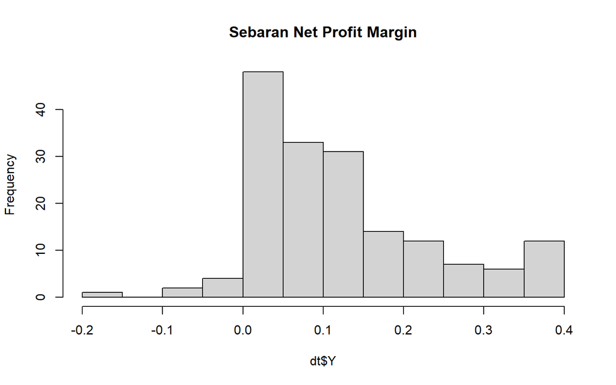

```r
hist(dt$Y, main = "Sebaran Net Profit Margin")
```

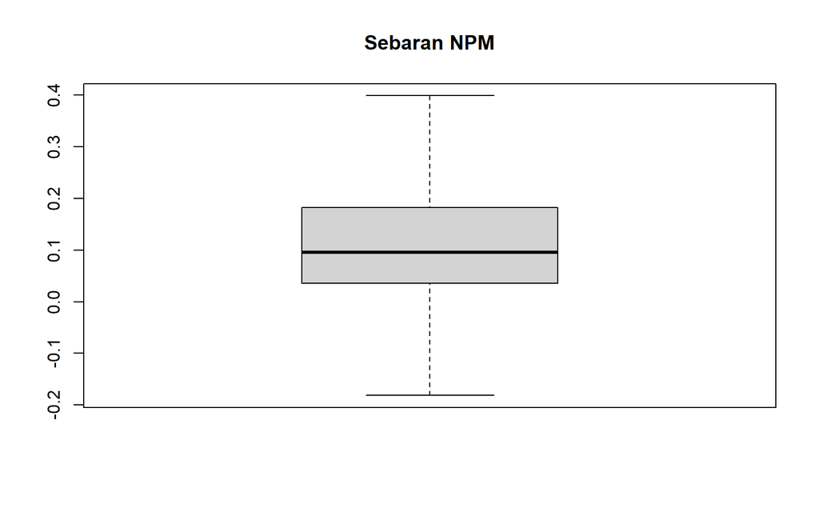

```r
boxplot(dt$Y, main = "Sebaran NPM")
```

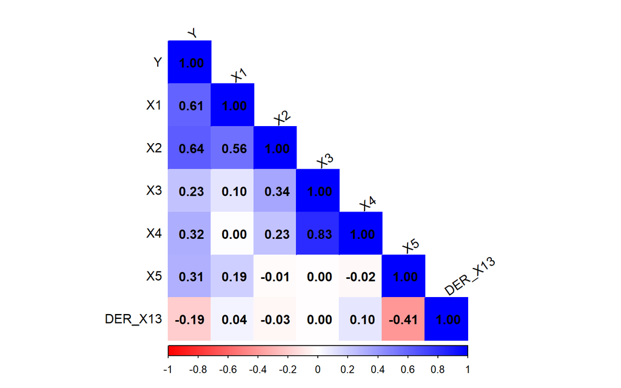

```r
library(ggplot2)
library(corrplot)
cor_matrix <- cor(dt, use = "complete.obs")

corrplot(cor_matrix, method = "color", type = "lower",
         col = colorRampPalette(c("red", "white", "blue"))(200),
         addCoef.col = "black", tl.col = "black", tl.srt = 35)
```

Berdasarkan visualisasi korelogram, nilai koefisien korelasi Pearson antara variabel respon ($Y$) dengan seluruh variabel prediktor ($X_1, X_2, X_3, X_4, X_5$) menunjukkan hubungan linear positif. Seluruh nilai korelasi bernilai positif (berwarna biru), yang berarti jika variabel prediktor meningkat, maka nilai Net Profit Margin ($Y$) juga cenderung meningkat.

**Korelasi Antara Variabel Respon ($Y$) dengan Variabel Prediktor**

- X2 memiliki hubungan paling kuat dengan variabel respon Y (r = 0,64), diikuti oleh X1 (r = 0,61). Hal ini menunjukkan bahwa peningkatan nilai X1 dan X2 cenderung diikuti oleh peningkatan nilai Y.
- Variabel X3, X4, dan X5 hanya memiliki hubungan positif yang lemah terhadap Y sehingga kontribusinya secara individual relatif lebih kecil dibandingkan X1 dan X2.

**Korelasi Antar variabel bebas**

-Sebagian besar pasangan variabel bebas memiliki korelasi rendah hingga sedang.

-Pasangan X3 dan X4 memiliki korelasi yang sangat kuat (r = 0,83). Hal ini mengindikasikan bahwa kedua variabel membawa informasi yang hampir sama sehingga perlu diwaspadai adanya indikasi multikolinearitas apabila digunakan bersama dalam model regresi.

**IIndikasi Multikolinieritas**

- X3 dan X4 memiliki korelasi sebesar 0,83, sehingga terdapat indikasi adanya multikolinearitas pada pasangan variabel tersebut.
- Pasangan variabel bebas lainnya memiliki korelasi di bawah 0,80 sehingga belum menunjukkan masalah multikolinearitas yang serius.

# Pemodelan

## Tanpa Fungsi

Perhitungan nilai $\hat{\beta}$ secara matriks dapat dilakukan dengan rumus berikut.

$$\hat{\beta} = (X'X)^{-1}
X'y$$

```r
# pembentukan matriks
n <- nrow(dt)
x0 <- rep(1,n)
x <- data.frame(x0, dt$X1, dt$X2, dt$X3, dt$X4,
                dt$X5)
x <- as.matrix(x)
y <- dt$Y
```

```r
beta_duga <- solve(t(x)%*%x)%*%t(x)%*%y
beta_duga
```

```
##              [,1]
## x0    -0.04819606
## dt.X1  0.17934577
## dt.X2  0.36184532
## dt.X3 -1.07423345
## dt.X4  0.60138723
## dt.X5  0.01525463
```

Selang kepercayaan dan pengujian signifikansi setiap parameter dapat dilakukan dengan menghitung keragaman tiap dugaan parameter. Secara umum, nilai ragam dugaan parameter $\hat{\beta}_j$ dapat dihitung melalui rumus berikut.

$$Var(\hat{\beta}_j) = \hat{\sigma}^2
C_{jj}$$
Dengan matriks $C$ adalah matriks $(X'X)^{-1}$

```r
c <- data.frame(solve(t(x)%*%x))
```

Unsur diagonal dari matriks $C$ dapat digunakan untuk menghitung nilai galat baku dari setiap dugaan parameter. Galat baku ini dapat digunakan untuk menghitung selang kepercayaan dari dugaan yang dihasilkan.

$$SE(\hat{\beta}_j) =
\sqrt{Var(\hat{\beta}_j)} = \sqrt{\sigma^2 C_{jj}} =
\hat{\sigma}\sqrt{c_{ii}}$$

Misal ingin dihitung selang kepercayaan dari dugaan parameter $\beta_2$, maka

```r
y_hat <- x %*% beta_duga
residuals <- y - y_hat
n <- nrow(x)
p <- ncol(x)
KTG <- sum(residuals^2) / (n - p)

c22 <- c[2,2]

(se.b2 <- sqrt(KTG*c22))
```

```
## [1] 0.02970728
```

```r
alfa <- 0.05

#Batas Bawah beta2
(bb.b2 <- beta_duga[3,1] - abs(qt(alfa/2, df=n-p))*se.b2)
```

```
##     dt.X2
## 0.3031873
```

```r
#Batas Atas beta2
(ba.b2 <- beta_duga[3,1] + abs(qt(alfa/2, df=n-p))*se.b2)
```

```
##     dt.X2
## 0.4205034
```

# Dengan Fungsi

```r
model1 <- lm(formula = Y ~ ., data = dt)
summary(model1)
```

```
##
## Call:
## lm(formula = Y ~ ., data = dt)
##
## Residuals:
##       Min        1Q    Median        3Q       Max
## -0.190481 -0.036879 -0.004817  0.028438  0.284081
##
## Coefficients:
##               Estimate Std. Error t value Pr(>|t|)
## (Intercept) -0.0201755  0.0143001  -1.411 0.160191
## X1           0.2030813  0.0293015   6.931 9.26e-11 ***
## X2           0.3374468  0.0442438   7.627 1.89e-12 ***
## X3          -1.1805581  0.2005783  -5.886 2.19e-08 ***
## X4           0.6628448  0.0837587   7.914 3.62e-13 ***
## X5           0.0104320  0.0029171   3.576 0.000459 ***
## DER_X13     -0.0005041  0.0001351  -3.730 0.000264 ***
## ---
## Signif. codes:  0 '***' 0.001 '**' 0.01 '*' 0.05 '.' 0.1 ' ' 1
##
## Residual standard error: 0.06547 on 163 degrees of freedom
## Multiple R-squared:  0.6916, Adjusted R-squared:  0.6802
## F-statistic: 60.92 on 6 and 163 DF,  p-value: < 2.2e-16
```

# Pemeriksaan Multikoliniearitas

```r
library(car)
vif(model1)
```

```
##       X1       X2       X3       X4       X5  DER_X13
## 1.647669 1.718986 3.465756 3.331961 1.316183 1.296828
```

Tidak ada multikolinearitas karena seluruh nilai VIF dibawah 10.

```r
summary(model1)
```

```
##
## Call:
## lm(formula = Y ~ ., data = dt)
##
## Residuals:
##       Min        1Q    Median        3Q       Max
## -0.190481 -0.036879 -0.004817  0.028438  0.284081
##
## Coefficients:
##               Estimate Std. Error t value Pr(>|t|)
## (Intercept) -0.0201755  0.0143001  -1.411 0.160191
## X1           0.2030813  0.0293015   6.931 9.26e-11 ***
## X2           0.3374468  0.0442438   7.627 1.89e-12 ***
## X3          -1.1805581  0.2005783  -5.886 2.19e-08 ***
## X4           0.6628448  0.0837587   7.914 3.62e-13 ***
## X5           0.0104320  0.0029171   3.576 0.000459 ***
## DER_X13     -0.0005041  0.0001351  -3.730 0.000264 ***
## ---
## Signif. codes:  0 '***' 0.001 '**' 0.01 '*' 0.05 '.' 0.1 ' ' 1
##
## Residual standard error: 0.06547 on 163 degrees of freedom
## Multiple R-squared:  0.6916, Adjusted R-squared:  0.6802
## F-statistic: 60.92 on 6 and 163 DF,  p-value: < 2.2e-16
```

# Uji Hipotesis Kesamaan Parameter Regresi

Dari pemodelan sebelumnya, diperoleh persamaan regresi

$$\hat{Y}=-0.048196+0.179346X_1+0.361845X_2-1.074233X_3+
0.601387+0.015255X_5$$

Hipotesis yang diuji adalah

$$H_0: β2=β4$$
$$H_1: β2≠β4$$

$$PPM=β_0+β_2X_2+β_4X_4+ε$$
Jika $H_0$ benar $(β_2=β_4=β_1')$, model bisa ditulis ulang sebagai

$$Y=β_0+β_1' (X_2+X_4)+ε$$

```r
# Buat peubah baru
dt$X_new <- dt$X2 + dt$X4

# Model penuh (Full Model)
model_full <- lm(Y ~ X2 + X4, data = dt)

# Model terbatas (Restricted Model)
model_restricted <- lm(Y ~ X_new, data = dt)

# Bandingkan dengan Uji F
anova(model_restricted, model_full)
```

```
## Analysis of Variance Table
##
## Model 1: Y ~ X_new
## Model 2: Y ~ X2 + X4
##   Res.Df    RSS Df Sum of Sq      F   Pr(>F)
## 1    168 1.3549
## 2    167 1.2772  1  0.077724 10.163 0.001711 **
## ---
## Signif. codes:  0 '***' 0.001 '**' 0.01 '*' 0.05 '.' 0.1 ' ' 1
```

```r
model_all <- lm(Y ~ X1+X2+X3+X4+X5, data = dt)
summary(model_all)
```

```
##
## Call:
## lm(formula = Y ~ X1 + X2 + X3 + X4 + X5, data = dt)
##
## Residuals:
##       Min        1Q    Median        3Q       Max
## -0.177123 -0.033002 -0.003361  0.027531  0.296120
##
## Coefficients:
##              Estimate Std. Error t value Pr(>|t|)
## (Intercept) -0.048196   0.012639  -3.813 0.000194 ***
## X1           0.179346   0.029707   6.037 1.01e-08 ***
## X2           0.361845   0.045448   7.962 2.67e-13 ***
## X3          -1.074233   0.206213  -5.209 5.62e-07 ***
## X4           0.601387   0.085295   7.051 4.72e-11 ***
## X5           0.015255   0.002716   5.617 8.17e-08 ***
## ---
## Signif. codes:  0 '***' 0.001 '**' 0.01 '*' 0.05 '.' 0.1 ' ' 1
##
## Residual standard error: 0.068 on 164 degrees of freedom
## Multiple R-squared:  0.6652, Adjusted R-squared:  0.655
## F-statistic: 65.18 on 5 and 164 DF,  p-value: < 2.2e-16
```

```r
model_signif <- lm(Y ~ X2+X4, data = dt)
summary(model_signif)
```

```
##
## Call:
## lm(formula = Y ~ X2 + X4, data = dt)
##
## Residuals:
##      Min       1Q   Median       3Q      Max
## -0.14526 -0.04409 -0.02328  0.01980  0.45212
##
## Coefficients:
##             Estimate Std. Error t value Pr(>|t|)
## (Intercept)  0.02912    0.01129   2.580  0.01074 *
## X2           0.46263    0.04635   9.982  < 2e-16 ***
## X4           0.18694    0.06302   2.966  0.00346 **
## ---
## Signif. codes:  0 '***' 0.001 '**' 0.01 '*' 0.05 '.' 0.1 ' ' 1
##
## Residual standard error: 0.08745 on 167 degrees of freedom
## Multiple R-squared:  0.4362, Adjusted R-squared:  0.4295
## F-statistic: 64.61 on 2 and 167 DF,  p-value: < 2.2e-16
```

```r
perbandingan <- data.frame(
  Model = c("Peubah Penuh", "Dua Peubah"),
  Adjusted_R2 = as.numeric(c(summary(model_all)$adj.r.squared, summary(model_signif)$adj.r.squared)),
  AIC = as.numeric(c(AIC(model_all), AIC(model_signif))),
  BIC = as.numeric(c(BIC(model_all), BIC(model_signif)))
)
perbandingan
```

```
##          Model Adjusted_R2       AIC       BIC
## 1 Peubah Penuh   0.6550377 -423.6753 -401.7247
## 2   Dua Peubah   0.4294594 -341.0583 -328.5151
```

Berdasarkan indikator Adjusted R square, AIC, dan BIC maka model dengan semua peubah dipilih sebagai model yang terbaik. Persamaan yang terbentuk adalah sebagai berikut

$$\hat{Y}=-0.048196+0.179346X_1+0.361845X_2-1.074233X_3+
0.601387+0.015255X_5$$
Interpretasi:
Berdasarkan tanda koefisien regresi, variabel $X_1$, $X_2$, $X_4$, dan $X_5$ memiliki pengaruh positif terhadap variabel respon $Y$, sedangkan $X_3$ memiliki pengaruh negatif. Di antara seluruh prediktor, $X_3$ memiliki pengaruh paling besar secara absolut dengan koefisien sebesar $-1,074233$, sehingga perubahan pada variabel ini diperkirakan memberikan dampak terbesar terhadap nilai prediksi $Y$. Sementara itu, $X_5$ memiliki pengaruh yang paling kecil terhadap variabel respon karena koefisien regresinya hanya sebesar $0,015255$.